# Ranking ubóstwa w UE

W ostatnim tygodniu trafiłam na artykuł dotyczący odsetka ludzi narażonych na ryzyko ubóstwa i wykluczenia społecznego ( źródło : http://biznes.onet.pl/wiadomosci/ue/ranking-ubostwa-w-ue-porownanie-2008-z-2015/hcxtrl ). Postanowiłam przedstawić zawarte dane w podziale ze względu na rok. Oba wykresy zostały posortowane ze względu na malejący odsetek osób zagrożonych ubóstwem i wykluczeniem społecznym. Kolory zostały przydzielone ze względu na podział, który pojawił się w artykule - “Kraje z najwyższym ryzykiem w 2015”, “Kraje z najniższym ryzykiem w 2015”, “Kraje z najwyższym wzrostem ryzyka w stosunku do 2008”. Oddzielnym kolorem zostały zaznaczone słupki z danymi dla Polski.

Patrząc na poniższy wykres od razu możemy zauważyć, że rozkład rozkład ryzyka w rozpatrywanych państwach UE jest bardzo podobny- w 2008 roku podobnie do 2015 Bułgaria, Rumunia, Łotwa i Grecja mają największe wartości, a Finlandia, Holandia, Szwecja i Czechy najmniejsze. Bułgaria utrzymała swoją pierwszą pozycję w rankingu, natomiast Holandia, która w 2008 cechowała się najniższym poziomem wskaźnika, odnotowała jego wzrost i znalazła się na 9 miejscu. Większość z państw z najwyższym poziomem ryzyka w 2015 cechuje się jego spadkiem względem 2008- jedynie dla Grecji wskażnik wzrósł aż o 7.6 p.p. co czyni ją jednym z państw o najwyższym wzroście.

Widać, że Polska z państwa, które w 2008 znajdowało się w czołówce rankingu, odnotowała spadek z 30.5 do 23.4 i znajduje się w grupie ze średnim poziomem ryzyka ubóstwa.

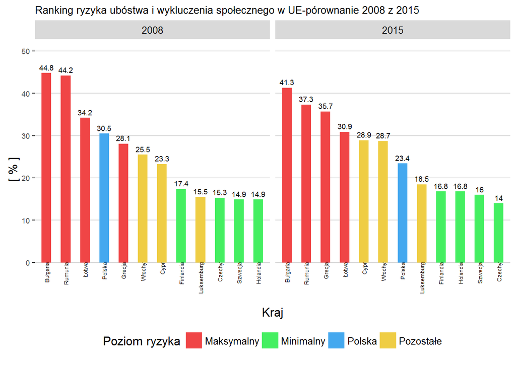

```r
dane<-read.csv("C:/Users/Agnieszka/Desktop/Dane2.csv", h=T, sep=";")
dane2     <- dane[order(dane$Rok,-dane$Wartosc),]
dane2$p <- with(dane2,paste(Kraj,Rok,sep="."))

ggplot(dane2[dane2$Rok %in% unique(dane$Rok),],
  aes(x=factor(p,levels=unique(p)), y=Wartosc, fill=Indeks,width=.5)) +
  geom_bar(stat = "identity") +
  geom_text(aes(y=0.1,label=Kraj),angle=90,size=2,hjust=1)+
  geom_text(aes(y=Wartosc,label=Wartosc), size=2.5,hjust=0.5,vjust=-0.5)+
  facet_wrap(~Rok, ncol = 2, scales="free_x") +
  ylim(-6,50)+
  labs(title="Ranking ryzyka ubóstwa i wykluczenia społecznego w UE-pórownanie 2008 z 2015",
     x="Kraj", y="[ % ]") +
  theme(axis.text.x=element_blank(),axis.ticks.x=element_blank(),
    axis.text=element_text(size=7), legend.position="bottom",
    plot.title = element_text(size = 10, hjust = 0))+
    theme_hc() +
  scale_fill_manual(name="Poziom ryzyka",
    values=c("#f04546", "#44ef61", "#44a8ef", "#efcd44"))
```